# Data analysis

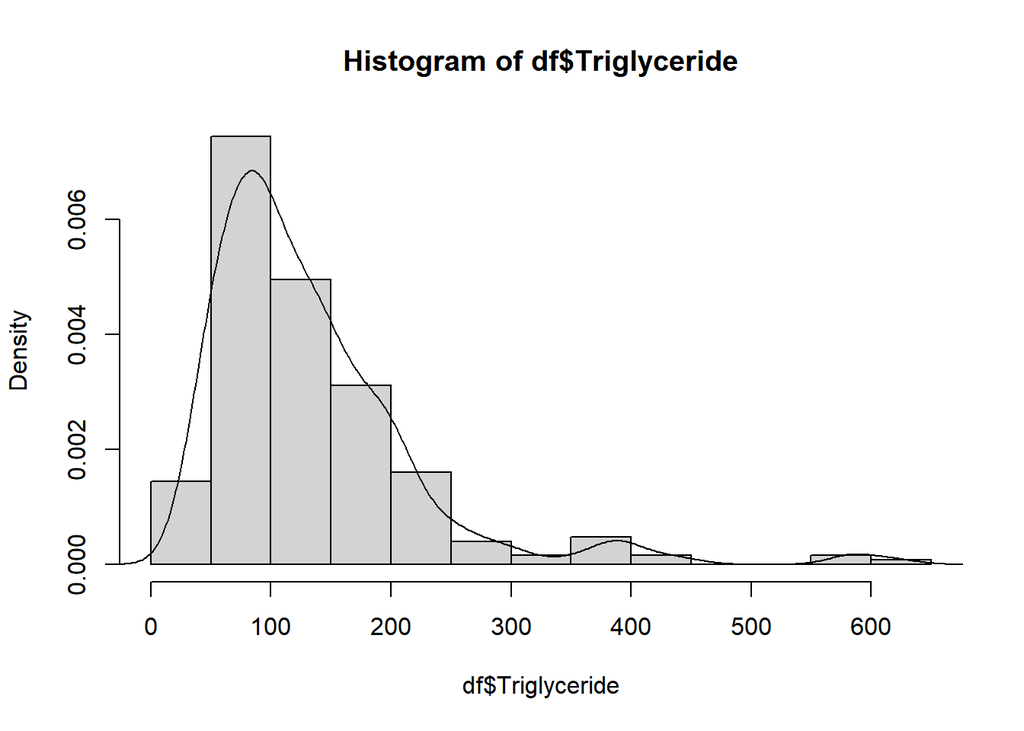

```r
# Histrogram plot on density
hist(df$Triglyceride,freq = F,prob = T)
lines(density(df$Triglyceride))
```

All independent variables are then plotted against Triglyceride to determine whether or not a correlation exist. Based on the plots, variables that appear to affect Triglyceride level are Cholesterol that is increasing, HDL decreasing, Smoking 2 decreasing, cigarettes increasing, Alcohol increasing, Blood_sugar increasing. By viewing the histogram, It appears the highest frequency of Triglyceride is around 50-100. Reaching its peak there and slowly lowering until 300. At which point it switches between up and down. Therefore the data is right skewed. Indicating the data is not normally distributed. There are also outliers when Triglyceride is around 600 .

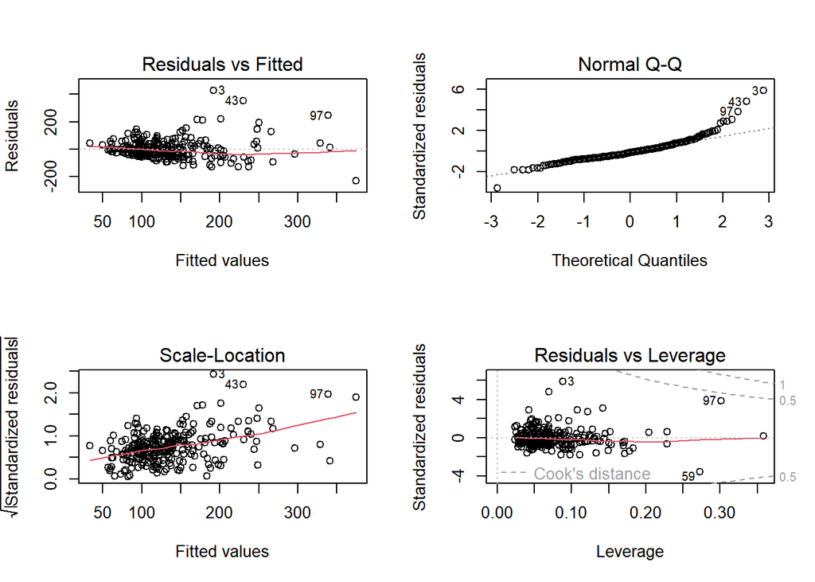

```r
#Creates residual , normal QQ and standardized residuals plots
par(mfrow=c(2,2))
plot(lm_full)
```